## Exercise 5

In our regression analysis, the response variable is “expend” and the explanatory variables are: “bad, crime, lawyers, employ and pop”. The purpose is to explain expend by a numerical function of the explanatory variables.

**a)** First, we make a graphical summary of the data by plotting each variable against the others. Furthermore, we construct a histogram of all the numerical variables. Looking at the plots, we observe that expend, laywers, employ and pop all approximate a linear relationship with all the other variables. Furthermore, state and crime have nonlinear relationhsips with all the other variables. Lastly, the variable bad can be argued to have a weak linear relationship with the variables expend, lawyers, employ and pop. Looking at the histograms, it is interesting to see that almost all variables (expend, bad, laywers, employ and pop) follow a similar pattern, namely, the lowest value appears frequently and as the value increases, the frequency decreases steeply. Except for a few outliers of frequently occuring high values. In contrast, the variable crime shows a different pattern. Namely, the values in the middle occur also relatively frequently. But the rule: as the value increases, the frequency decreases, applies as well.

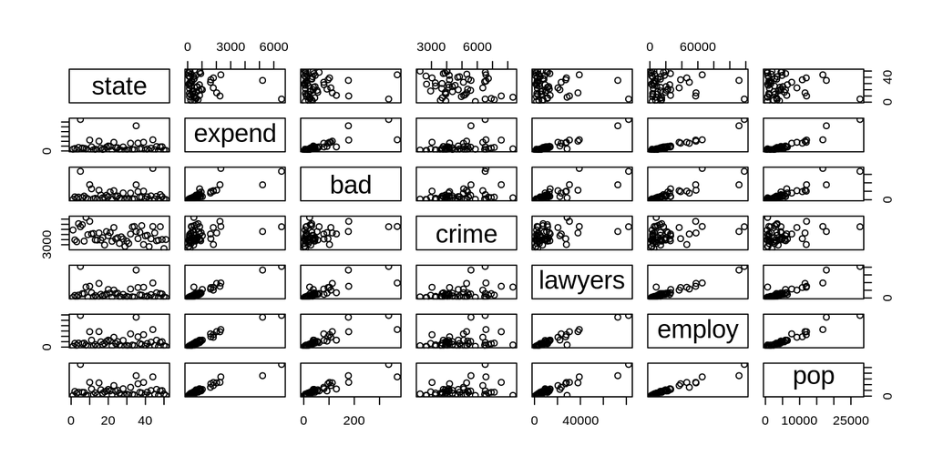

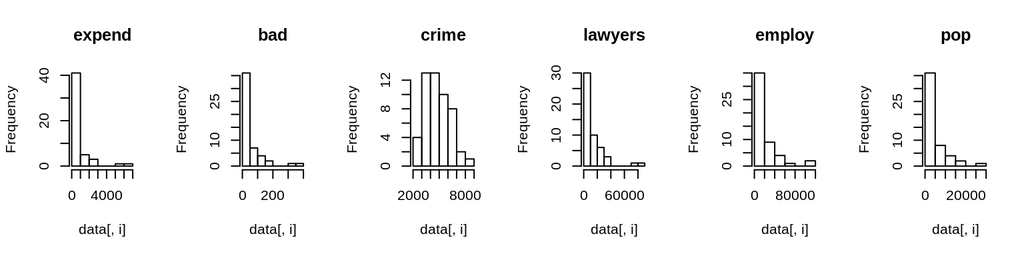

A potential point is an outlier in an explanatory variable. The effect can be studied by fitting the model with and without the potential point. If the estimated parameters change drastically when removing the potenetial point, the observation is called an influence point. Using the Cook’s formula, the distance of an observation on the predictions can be calculated. Whenever the Cook’s distance for an observation approximates or is larger than 1, the observation can be considered to be an influence point. Another relevent concept is collinearity. This is the problem of linear relations between explanatory variables. Collinearity can be detected by a straight line in a scatter plot or by calculating the correlation coefficient. Looking at the scatter plots of the data, we suspect collinearity between the variables expend, lawyers, employ and pop. We confirm this by calculating the correlaction coeffiecients of all possible variable combinations. Looking at the output below, we observe that all the combinations of the variables expend, lawyers, employ and pop have a correlation coefficient above 93. Thus, we conclude that these variables have a collinear relation. The variable bad has a weaker collinear relation with the variables expend, lawyers, employ and pop, namely, ranging from 0.83 to 0.93. Lastly, the variable crime has no collinear relation with any of the other variables. When collinearity is detected among variables, we should avoid having both explanatory variables in the model.

```
##         expend  bad crime lawyers employ  pop
## expend    1.00 0.83  0.33    0.97   0.98 0.95
## bad       0.83 1.00  0.37    0.83   0.87 0.92
## crime     0.33 0.37  1.00    0.38   0.31 0.28
## lawyers   0.97 0.83  0.38    1.00   0.97 0.93
## employ    0.98 0.87  0.31    0.97   1.00 0.97
## pop       0.95 0.92  0.28    0.93   0.97 1.00
```

**b)**

To fit a linear regression model to the data, first, we start with the step-up method. Using this method, we start by fitting all possible simple linear regression models and calculate the determination coefficient ($R^{2}$). The results are shown in the table below. Looking at this table, we observe that employ has the largerst value of $R^{2}$ (0.954) and is thus selected. Next, we combine this variable with all the variables that do not have a collinear relation with employ. These are the explanatory variables bad and crime. Note that the variable bad still can be considered to be linearly correlated to employ. Adding the variables bad and crime to the models yields in $R^{2}$ = 0.9551. This is an improvement compared to the previous model. Therefore, we continue to add the other vairables to the model. For both models, there is just one variable to add. This results in the last possible option: a model of employ, bad and crime combined. This result in $R^{2}$ = 0.9568, the highest value so far. As there are no more variables to add, the method stops here. The resulting model is: expense = -2.857$e^{+02}$ + 4.979$e^{-02}$ * employ - 1.391$e^{+00}$ * bad + 3.810$e^{-02}$ * crime + error. We have to be carefull as it could be argued that the variables employ and bad are collinear. Therefore, the model that is constructed with the variables employ and crime (expense = -2.484$e^{+02}$ + 4.630$e^{-02}$ * employ + 2.962$e^{-02}$ * crime + error) might be a better model as it contains fewer variables and the value of $R^{2}$ is similar.

| **Explantory Variable(s)** | bad | crime | laywers | employ | pop | employ, bad | employ, crime | employ, bad, crime |
| --- | --- | --- | --- | --- | --- | --- | --- | --- |
| **Multiple R-squared** | 0.6964 | 0.1119 | 0.9373 | 0.954 | 0.9073 | 0.9551 | 0.9551 | 0.9568 |

Second, we use the step-down method. This method start with fitting all explanatory variables in the so-called full model. In each iteration, one explanatory variable is removed. This time, we try the model with all variables, regardless of collinearity. In round 1, we observe that the variable crime has the highest p-value, 0.25534 > 0.05, therefore, the variable crime will be removed. In round 2, pop has the highest p-value, 0.06012 > 0.05, therefore, the variable pop will be removed. In round 3, bad has the highest p-value, 0.34496 > 0.05, therefore, the variable bad will be removed. In round 4, laywers has the highest p-value, 0.00113 < 0.05, therefore, the variable will not be removed and the method stops. This results in the model expense = -1.107$e^{+02}$ + 2.686$e^{-02}$ * laywers + 2.971$e^{-02}$ * employ + error.

```r
summary(lm(expend~bad+crime+lawyers+employ+pop,data=data))
```

```
##
## Call:
## lm(formula = expend ~ bad + crime + lawyers + employ + pop, data = data)
##
## Residuals:
##     Min      1Q  Median      3Q     Max
## -638.41  -87.42   22.15  114.96  804.98
##
## Coefficients:
##               Estimate Std. Error t value Pr(>|t|)
## (Intercept) -2.991e+02  1.401e+02  -2.136  0.03817 *
## bad         -2.832e+00  1.240e+00  -2.283  0.02719 *
## crime        3.241e-02  2.813e-02   1.152  0.25534
## lawyers      2.324e-02  8.044e-03   2.890  0.00592 **
## employ       2.297e-02  7.462e-03   3.078  0.00354 **
## pop          7.787e-02  3.515e-02   2.215  0.03184 *
## ---
## Signif. codes:  0 '***' 0.001 '**' 0.01 '*' 0.05 '.' 0.1 ' ' 1
##
## Residual standard error: 225.6 on 45 degrees of freedom
## Multiple R-squared:  0.9675, Adjusted R-squared:  0.9639
## F-statistic: 268.2 on 5 and 45 DF,  p-value: < 2.2e-16
```

```r
summary(lm(expend~bad+lawyers+employ+pop,data=data))
```

```
##
## Call:
## lm(formula = expend ~ bad + lawyers + employ + pop, data = data)
##
## Residuals:
##     Min      1Q  Median      3Q     Max
## -635.62  -80.18   18.77  114.54  809.66
##
## Coefficients:
##               Estimate Std. Error t value Pr(>|t|)
## (Intercept) -1.464e+02  4.541e+01  -3.224  0.00232 **
## bad         -2.241e+00  1.133e+00  -1.977  0.05402 .
## lawyers      2.646e-02  7.571e-03   3.495  0.00106 **
## employ       2.283e-02  7.487e-03   3.049  0.00380 **
## pop          6.368e-02  3.304e-02   1.927  0.06012 .
## ---
## Signif. codes:  0 '***' 0.001 '**' 0.01 '*' 0.05 '.' 0.1 ' ' 1
##
## Residual standard error: 226.4 on 46 degrees of freedom
## Multiple R-squared:  0.9666, Adjusted R-squared:  0.9637
## F-statistic: 332.5 on 4 and 46 DF,  p-value: < 2.2e-16
```

```r
summary(lm(expend~bad+lawyers+employ,data=data))
```

```
##
## Call:
## lm(formula = expend ~ bad + lawyers + employ, data = data)
##
## Residuals:
##     Min      1Q  Median      3Q     Max
## -631.75  -93.69   30.34   89.68  963.67
##
## Coefficients:
##               Estimate Std. Error t value Pr(>|t|)
## (Intercept) -1.106e+02  4.261e+01  -2.595  0.01257 *
## bad         -8.627e-01  9.042e-01  -0.954  0.34496
## lawyers      2.631e-02  7.786e-03   3.379  0.00147 **
## employ       3.232e-02  5.803e-03   5.569  1.2e-06 ***
## ---
## Signif. codes:  0 '***' 0.001 '**' 0.01 '*' 0.05 '.' 0.1 ' ' 1
##
## Residual standard error: 232.8 on 47 degrees of freedom
## Multiple R-squared:  0.9639, Adjusted R-squared:  0.9616
## F-statistic:   418 on 3 and 47 DF,  p-value: < 2.2e-16
```

```r
summary(lm(expend~lawyers+employ, data=data))
```

```
##
## Call:
## lm(formula = expend ~ lawyers + employ, data = data)
##
## Residuals:
##     Min      1Q  Median      3Q     Max
## -599.47  -94.43   36.01   91.98  936.55
##
## Coefficients:
##               Estimate Std. Error t value Pr(>|t|)
## (Intercept) -1.107e+02  4.257e+01  -2.600  0.01236 *
## lawyers      2.686e-02  7.757e-03   3.463  0.00113 **
## employ       2.971e-02  5.114e-03   5.810 4.89e-07 ***
## ---
## Signif. codes:  0 '***' 0.001 '**' 0.01 '*' 0.05 '.' 0.1 ' ' 1
##
## Residual standard error: 232.6 on 48 degrees of freedom
## Multiple R-squared:  0.9632, Adjusted R-squared:  0.9616
## F-statistic: 627.7 on 2 and 48 DF,  p-value: < 2.2e-16
```

**c)**

We check the model assumptions (linearity of the relation and normality of the errors) using both graphical and numerical tools.

We cannot assume normality.

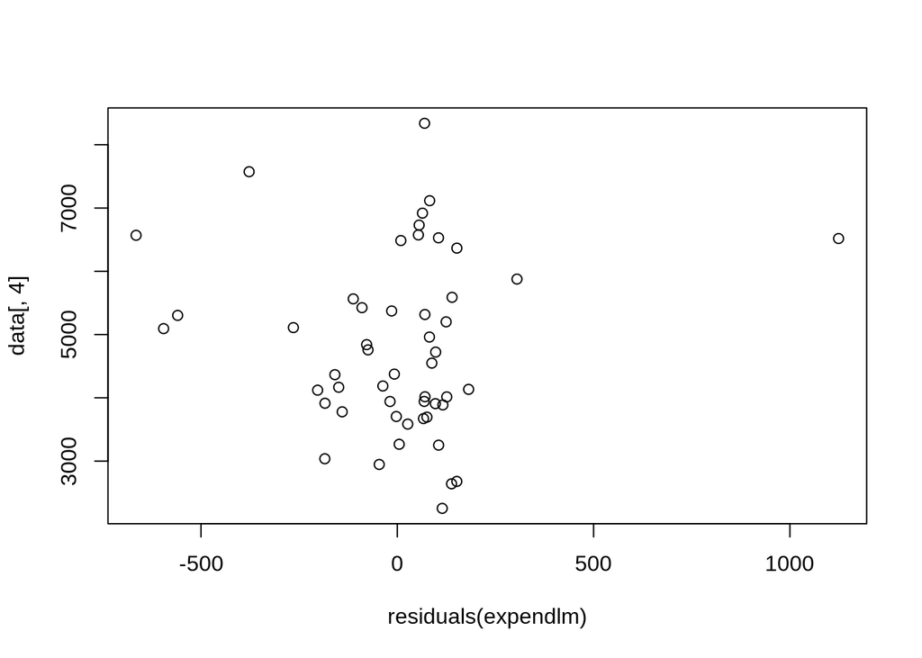

```r
#1 Scatter plot of Y against each X k separately.
# done in previous exercise

#2 Scatter plot of residuals against each Xk in the model separately.
expendlm = lm(expend~employ+crime,data=data)
plot(residuals(expendlm),data[,4])
```

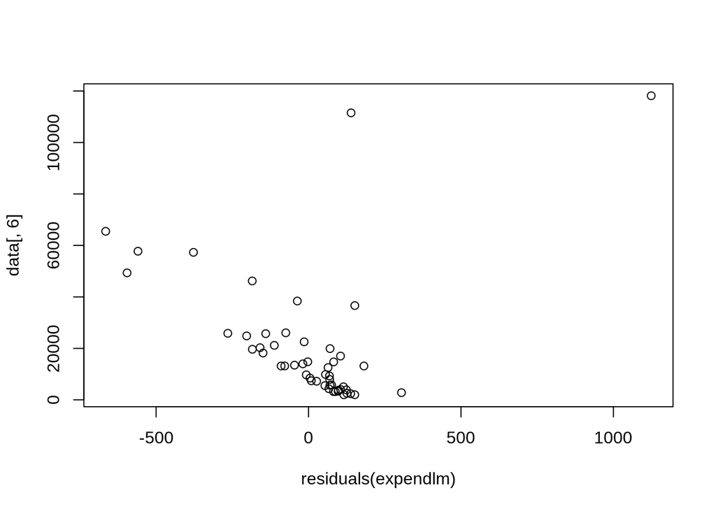

```r
plot(residuals(expendlm),data[,6])
```

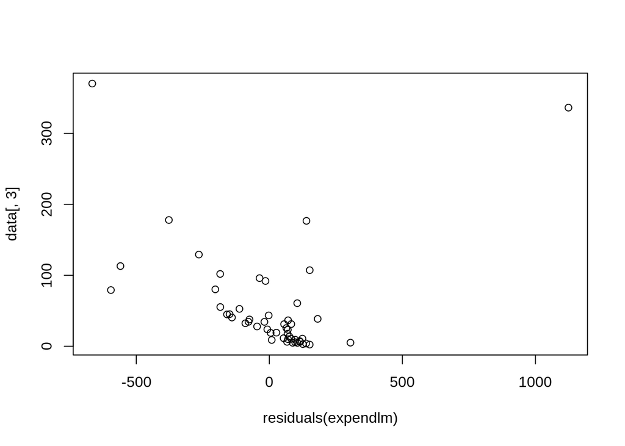

```r
#3 Added variable plot of residuals of Xj against residuals of Y with omitted Xj


#4 Scatter plot of residuals against each Xk not in the model separately
plot(residuals(expendlm),data[,3])
```

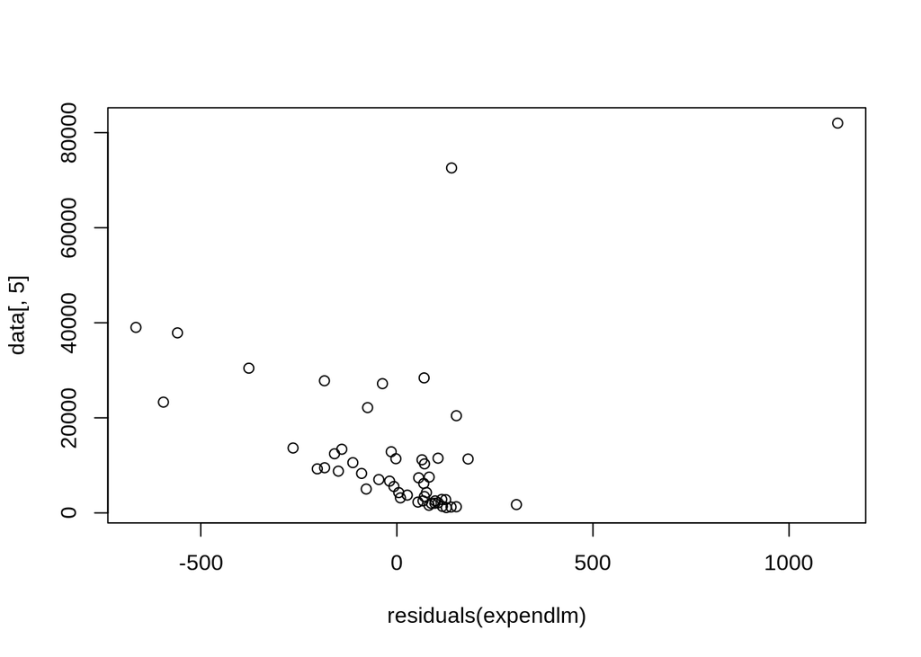

```r
plot(residuals(expendlm),data[,5])
```

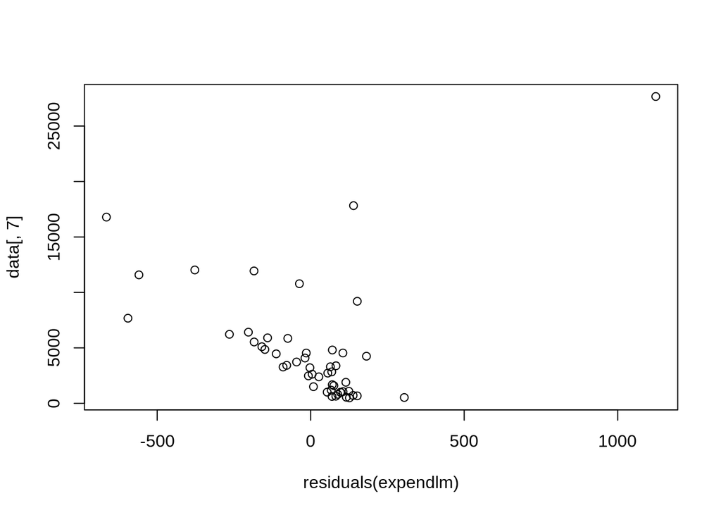

```r
plot(residuals(expendlm),data[,7])
```

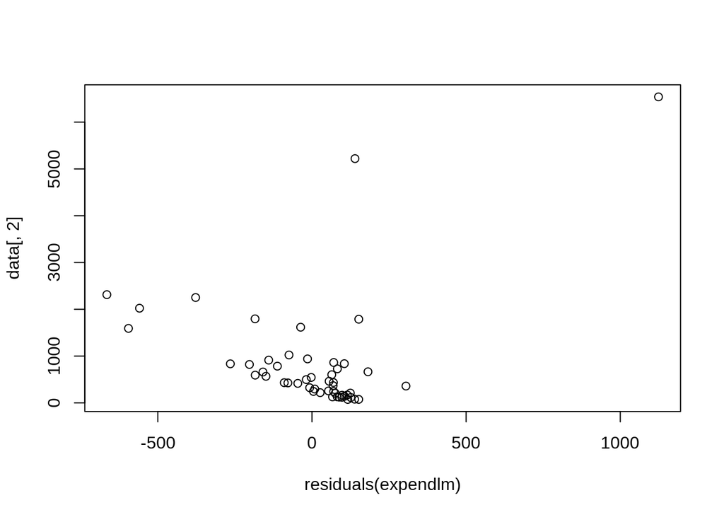

```r
#5 scatterplot of residuals against Y and Y^
plot(residuals(expendlm),data[,2])
```

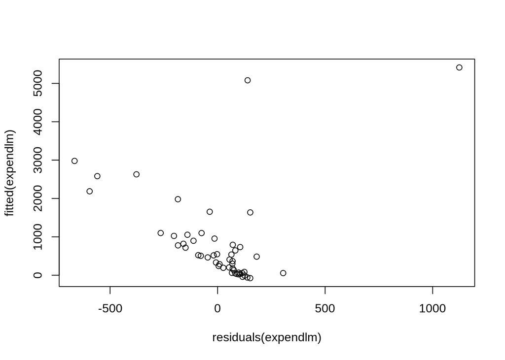

```r
plot(residuals(expendlm),fitted(expendlm))
```

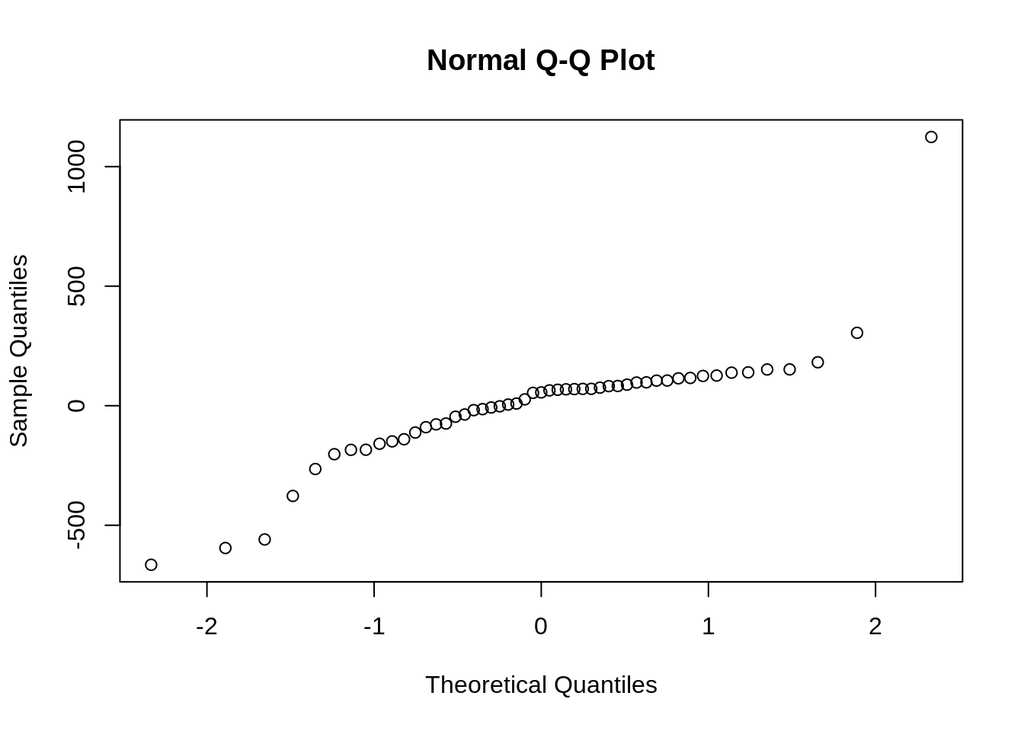

```r
#6 normal QQ-plot of the residuals and Shapiro-Wilk's method
qqnorm(residuals(expendlm))
```

```r
shapiro.test(residuals(expendlm))
```

```
##
##  Shapiro-Wilk normality test
##
## data:  residuals(expendlm)
## W = 0.79156, p-value = 4.622e-07
```